# python大大作业

### 从es中将数据导出csv文件

分布式爬虫系统是将从微博爬取的内容存储到es里面，但是es是搭建在内网之中，如果在寝室操作就不太方便，就将爬到es里面的数据导出为csv文件，在本地持久化，后面进行数据分析直接从本地取数据即可。爬取的特征的主要有：

- **id**: 微博id
- **NickName**: 微博昵称
- **Gender**: 性别
- **Province**: 省
- **City**: 市
- **VIPlevel**: vip等级
- **URL**: 微博链接
- **Birthday**: 生日
- **BriefIntroduction**: 简介
- **Authentication**: 认证方式

```python
import csv
import sys
import logging
import datetime
from elasticsearch import Elasticsearch

reload(sys)
sys.setdefaultencoding('utf-8')
logging.basicConfig()
es = Elasticsearch(['219.219.220.191'])


def exportCSV(indexName):
    count = 0
    finish = False
    csvfile = file(indexName + '.csv', 'wb')
    writer = csv.writer(csvfile)
    starttime = datetime.datetime.now()
    searchRes = es.search(index=indexName, size=100, body={"query": {"match_all": {}}}, scroll="60s")
    while True:
        scrollRes = es.scroll(scroll_id=searchRes["_scroll_id"], scroll="60s", ignore=[400, 404])
        res_list = scrollRes["hits"]["hits"]
        data = []

        if not len(res_list) or finish:
            break
        if count == 0:
            writer.writerow(tuple([
                u'id',
                u'NickName',
                u'Gender',
                u'Province',
                u'City',
                u'VIPlevel',
                u'URL',
                u'Birthday',
                u'BriefIntroduction',
                u'Authentication'
            ]))
        for item in res_list:
            # print tuple(item["_source"].values())
            # data.append(tuple(item["_source"].values()))
            data.append(tuple([
                item["_source"].get(u'id'),
                item["_source"].get(u'NickName'),
                item["_source"].get(u'Gender'),
                item["_source"].get(u'Province'),
                item["_source"].get(u'City'),
                item["_source"].get(u'VIPlevel'),
                item["_source"].get(u'URL'),
                item["_source"].get(u'Birthday'),
                item["_source"].get(u'BriefIntroduction'),
                item["_source"].get(u'Authentication')
            ]))
            count += 1
            if count >= 100000:
                finish = True
                break

        writer.writerows(data)
    csvfile.close()
    endtime = datetime.datetime.now()
    print "export size = " + str(count)
    print "export cost = " + str(endtime - starttime)


if __name__ == "__main__":
    exportCSV("info")
```

### 简单的看下爬到的数据

```python
import pandas as pd
from IPython.display import display
# 设置以内联的形式显示matplotlib绘制的图片（在notebook中显示更美观）
%matplotlib inline

data = pd.read_csv('info.csv')
display(data.head())
```

|  | id | NickName | Gender | Province | City | VIPlevel | URL | Birthday | BriefIntroduction | Authentication |
| --- | --- | --- | --- | --- | --- | --- | --- | --- | --- | --- |
| 0 | 3206773285 | roseonly诺誓 | 男 | 北京 | NaN | 6级 | http://weibo.com/roseonlyshop | 0001-00-00 | 高端爱情信物品牌，以“一生只爱一人”的真爱理念与矜贵花材甄选、精湛的工艺与设计闻名于世，产品... | 诺誓（北京）商业股份有限公司 |
| 1 | 1496070307 | 鹦鹉史航 | 男 | 北京 | NaN | 7级 | http://weibo.com/maguashihang | 2015-01-23 16:00:00 | 工作邀约，请联系赵先生，shihang_yingwu@163.com。有空翻翻我前面那些围脖... | 知名编剧、策划人、《鹦鹉话外音》主讲人、《奇葩说》第三季辩手 微博签约自媒体 |
| 2 | 1368283054 | 崔倓 | 男 | 海外 | 英国 | 6级 | http://weibo.com/cuitan1990 | 1990-09-11 16:00:00 | 北京电影学院表演学院09级本科班&amp | 演员，盛宏娱乐创始人 |
| 3 | 6058837784 | 范冰冰吧 | 男 | 北京 | NaN | 6级 | http://weibo.com/u/6058837784 | 处女座 | 百度范冰冰吧(前身范冰冰官网)开通于2003年，同年冰冰为粉丝“冰冰邦邦”正名以及统一应援口... | 范冰冰官方后援会 |
| 4 | 2387136224 | THE_GINZA | 女 | 海外 | NaN | 未开通 | http://weibo.com/u/2387136224 | NaN | THE GINZA，走在时代尖端的银座基因护肤品牌。就像是会与肌肤对话一般地，能感知肌肤的状... | THE_GINZA CO.,LTD |

简单的展示了下前5条数据，可以看到City特征缺失比较严重，Birthday特征数据格式比较多，并且第0条和第1条明显是随便填写的生日，所以这两个特征可能能提供的信息不多。能够获取有效信息的特征，目前来看主要有Gender，Province，VIPlevel,BriefIntroduction,Authentication这几个维度进行分析。

### 使用饼图查看爬到的大V的性别分布

我的预测：女性大V数量会比男性大V数量多。因为据我观察，周围玩微博的女生比较多，男生玩微博的比较少。 实验室朋友预测：男性大V数量会比女性daV数量多。觉得能沉下心梳理各种信息的，男性比女性多。

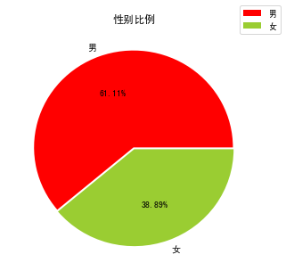

```python
import matplotlib.pyplot as plt

total = len(data['Gender'])

man_ratio = len(data['Gender'][data['Gender'] == '男']) / total
woman_ratio = len(data['Gender'][data['Gender'] == '女']) / total

plt.rcParams['font.family'] = 'sans-serif'
plt.rcParams['font.sans-serif'] = ['SimHei']
plt.rcParams['axes.unicode_minus'] = False
plt.figure(figsize=(5, 5))
sex_li = ['男', '女']
radius = [0.01, 0.01]
colors = ['red', 'yellowgreen']
proportion = [man_ratio, woman_ratio]

plt.pie(proportion, explode=radius, labels=sex_li, colors=colors, autopct='%.2f%%')

plt.legend(loc='upper right', fontsize=10, bbox_to_anchor=(1.1, 1.1), borderaxespad=0.3)

plt.title('性别比例')

plt.show()
```

由上图可以看出，这次爬取的大v，男性占比61.11%，女性占比38.89%，男性大V数量远超过女性大V数量。

### 柱状图分析大V数排名前10的省份

首先看下数据是否由缺失

```python
print(data.isnull().any())
```

```
id                   False
NickName             False
Gender               False
Province             False
City                  True
VIPlevel             False
URL                   True
Birthday              True
BriefIntroduction     True
Authentication        True
dtype: bool
```

- **isnull()**: 返回与原df相同shape的bool类型df，如果字段缺失则填充True，字段不缺失填充False
- **any()**: 默认按列计算，只要有True，则结果为True，只有全部为False，结果才为False

可以看到，id,NickName,Gender,Province,VIPlevel这几个字段是没有缺失的。其他字段均有缺失。既然Province没有数据缺失，暂时不用数据清洗，可以直接进行分析。

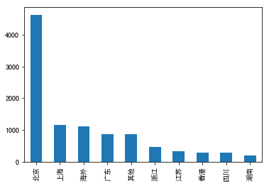

```python
data['Province'].value_counts()[:10].plot.bar()
plt.show()
```

### 使用词云分析最近微博热点

```
Building prefix dict from the default dictionary ...
Loading model from cache /var/folders/m7/6kcmf7n958x7y08m3yxp83l80000gn/T/jieba.cache
Loading model cost 0.883 seconds.
Prefix dict has been built succesfully.
```

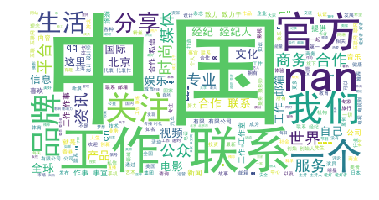

```python
import jieba
from wordcloud import WordCloud, ImageColorGenerator
import os
import numpy as np
import PIL.Image as Image
data['BriefIntroduction'] = data.applymap(str)['BriefIntroduction']
text = ''.join(data['BriefIntroduction'])
wordlist_jieba = jieba.cut(text, cut_all=True)
wl_space_split = ' '.join(wordlist_jieba)

alice_coloring = np.array(Image.open(os.path.join('timg.jpg')))

my_wordcloud = WordCloud(background_color='white', max_words=2000, max_font_size=150, random_state=42,
                         font_path='/usr/local/lib/python3.7/site-packages/matplotlib/mpl-data/fonts/ttf/SimHei.ttf').generate(wl_space_split)

# image_colors = ImageColorGenerator(alice_coloring)
# plt.imshow(my_wordcloud.recolor(color_func=image_colors))
plt.imshow(my_wordcloud)
plt.axis('off')
plt.show()
```

### 聚类分析

因为爬取的数据做聚类分析不太适合，从网上找了一份经典的数据集。

```python
# 引入这个项目需要的库
import numpy as np
import pandas as pd
import visuals as vs
from IPython.display import display # 使得我们可以对DataFrame使用display()函数

# 设置以内联的形式显示matplotlib绘制的图片（在notebook中显示更美观）
%matplotlib inline
try:
    data = pd.read_csv('customers.csv')
    data.drop(['Region', 'Channel'], axis=1, inplace=True)
    print 'Wholesale customers dataset has {} samples with {} features each.'.format(*data.shape)
except:
    print 'Dataset could not be loaded. Is the dataset missing?'
```

```
Wholesale customers dataset has 440 samples with 6 features each.
```

```python
display(data.describe())
```

|  | Fresh | Milk | Grocery | Frozen | Detergents_Paper | Delicatessen |
| --- | --- | --- | --- | --- | --- | --- |
| count | 440.000000 | 440.000000 | 440.000000 | 440.000000 | 440.000000 | 440.000000 |
| mean | 12000.297727 | 5796.265909 | 7951.277273 | 3071.931818 | 2881.493182 | 1524.870455 |
| std | 12647.328865 | 7380.377175 | 9503.162829 | 4854.673333 | 4767.854448 | 2820.105937 |
| min | 3.000000 | 55.000000 | 3.000000 | 25.000000 | 3.000000 | 3.000000 |
| 25% | 3127.750000 | 1533.000000 | 2153.000000 | 742.250000 | 256.750000 | 408.250000 |
| 50% | 8504.000000 | 3627.000000 | 4755.500000 | 1526.000000 | 816.500000 | 965.500000 |
| 75% | 16933.750000 | 7190.250000 | 10655.750000 | 3554.250000 | 3922.000000 | 1820.250000 |
| max | 112151.000000 | 73498.000000 | 92780.000000 | 60869.000000 | 40827.000000 | 47943.000000 |

```python
# 从数据集中选择三个你希望抽样的数据点的索引
indices = [100, 239, 430]

# 为选择的样本建立一个DataFrame
samples = pd.DataFrame(data.loc[indices], columns = data.keys()).reset_index(drop = True)
print "Chosen samples of wholesale customers dataset:"
display(samples)
```

```
Chosen samples of wholesale customers dataset:
```

|  | Fresh | Milk | Grocery | Frozen | Detergents_Paper | Delicatessen |
| --- | --- | --- | --- | --- | --- | --- |
| 0 | 11594 | 7779 | 12144 | 3252 | 8035 | 3029 |
| 1 | 47493 | 2567 | 3779 | 5243 | 828 | 2253 |
| 2 | 3097 | 4230 | 16483 | 575 | 241 | 2080 |

```python
new_data = data.drop('Detergents_Paper', axis = 1)
from sklearn.model_selection import train_test_split
X_train, X_test, y_train, y_test = train_test_split(new_data, data['Detergents_Paper'], test_size=0.25, random_state=40)

from sklearn.tree import DecisionTreeRegressor
regressor = DecisionTreeRegressor(random_state=0)
regressor.fit(X_train, y_train)
pred = regressor.predict(X_test)
score = regressor.score(X_test, y_test)
print(score)
```

```
0.787994241832
```

由上面结果可见，特征Detergents_Paper与其他特征的r2 score分数为0.79，比较接近1，说明购买Detergents_Paper的数量与其他特征有较大的相关性

### 可视化特征分布

创建一个散布矩阵

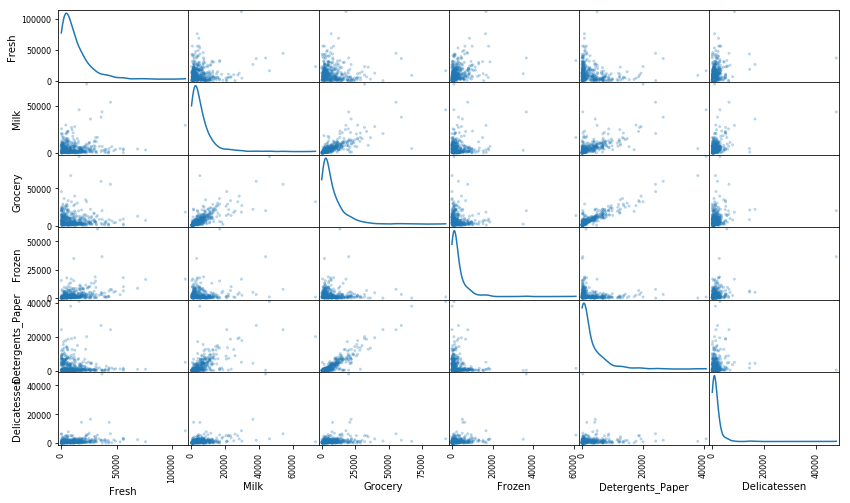

```python
pd.plotting.scatter_matrix(data, alpha = 0.3, figsize = (14,8), diagonal = 'kde');
```

可见数据分布并不是标准正态分布，大多数的数据点分布在峰值的右侧。所以需要进行数据预处理。

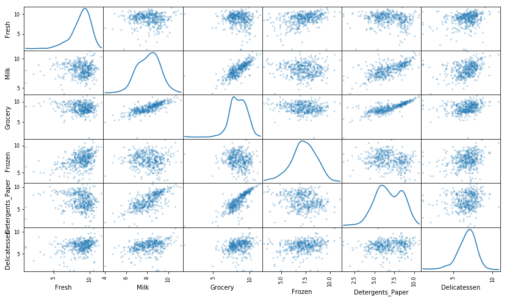

```python
# 使用自然对数缩放数据
log_data = np.log(data)
# 使用自然对数缩放样本数据
log_samples = np.log(samples)
# 为每一对新产生的特征制作一个散射矩阵
pd.plotting.scatter_matrix(log_data, alpha = 0.3, figsize = (14,8), diagonal = 'kde');
```

在使用了一个自然对数的缩放之后，数据的各个特征会显得更加的正态分布。对于有相关关系的特征对，他们的相关关系依然还是存在的

### 异常值检测

对于任何的分析，在数据预处理的过程中检测数据中的异常值都是非常重要的一步。异常值的出现会使得把这些值考虑进去后结果出现倾斜。这里有很多关于怎样定义什么是数据集中的异常值的经验法则。这里我们将使用Tukey的定义异常值的方法：一个异常阶（outlier step）被定义成1.5倍的四分位距（interquartile range，IQR）。一个数据点如果某个特征包含在该特征的IQR之外的特征，那么该数据点被认定为异常点。

```python
# 对于每一个特征，找到值异常高或者是异常低的数据点
for feature in log_data.keys():

    # 计算给定特征的Q1（数据的25th分位点）
    Q1 = np.percentile(log_data[feature], 25)

    # 计算给定特征的Q3（数据的75th分位点）
    Q3 = np.percentile(log_data[feature], 75)

    # 使用四分位范围计算异常阶（1.5倍的四分位距）
    step = 1.5 * (Q3 - Q1)

    # 显示异常点
    print("Data points considered outliers for the feature '{}':".format(feature))
    display(log_data[~((log_data[feature] >= Q1 - step) & (log_data[feature] <= Q3 + step))])

# 可选：选择你希望移除的数据点的索引
outliers  = [65, 66, 75, 128, 154]

# 如果选择了的话，移除异常点
good_data = log_data.drop(log_data.index[outliers]).reset_index(drop = True)
```

```
Data points considered outliers for the feature 'Fresh':
```

|  | Fresh | Milk | Grocery | Frozen | Detergents_Paper | Delicatessen |
| --- | --- | --- | --- | --- | --- | --- |
| 65 | 4.442651 | 9.950323 | 10.732651 | 3.583519 | 10.095388 | 7.260523 |
| 66 | 2.197225 | 7.335634 | 8.911530 | 5.164786 | 8.151333 | 3.295837 |
| 81 | 5.389072 | 9.163249 | 9.575192 | 5.645447 | 8.964184 | 5.049856 |
| 95 | 1.098612 | 7.979339 | 8.740657 | 6.086775 | 5.407172 | 6.563856 |
| 96 | 3.135494 | 7.869402 | 9.001839 | 4.976734 | 8.262043 | 5.379897 |
| 128 | 4.941642 | 9.087834 | 8.248791 | 4.955827 | 6.967909 | 1.098612 |
| 171 | 5.298317 | 10.160530 | 9.894245 | 6.478510 | 9.079434 | 8.740337 |
| 193 | 5.192957 | 8.156223 | 9.917982 | 6.865891 | 8.633731 | 6.501290 |
| 218 | 2.890372 | 8.923191 | 9.629380 | 7.158514 | 8.475746 | 8.759669 |
| 304 | 5.081404 | 8.917311 | 10.117510 | 6.424869 | 9.374413 | 7.787382 |
| 305 | 5.493061 | 9.468001 | 9.088399 | 6.683361 | 8.271037 | 5.351858 |
| 338 | 1.098612 | 5.808142 | 8.856661 | 9.655090 | 2.708050 | 6.309918 |
| 353 | 4.762174 | 8.742574 | 9.961898 | 5.429346 | 9.069007 | 7.013016 |
| 355 | 5.247024 | 6.588926 | 7.606885 | 5.501258 | 5.214936 | 4.844187 |
| 357 | 3.610918 | 7.150701 | 10.011086 | 4.919981 | 8.816853 | 4.700480 |
| 412 | 4.574711 | 8.190077 | 9.425452 | 4.584967 | 7.996317 | 4.127134 |

```
Data points considered outliers for the feature 'Milk':
```

|  | Fresh | Milk | Grocery | Frozen | Detergents_Paper | Delicatessen |
| --- | --- | --- | --- | --- | --- | --- |
| 86 | 10.039983 | 11.205013 | 10.377047 | 6.894670 | 9.906981 | 6.805723 |
| 98 | 6.220590 | 4.718499 | 6.656727 | 6.796824 | 4.025352 | 4.882802 |
| 154 | 6.432940 | 4.007333 | 4.919981 | 4.317488 | 1.945910 | 2.079442 |
| 356 | 10.029503 | 4.897840 | 5.384495 | 8.057377 | 2.197225 | 6.306275 |

```
Data points considered outliers for the feature 'Grocery':
```

|  | Fresh | Milk | Grocery | Frozen | Detergents_Paper | Delicatessen |
| --- | --- | --- | --- | --- | --- | --- |
| 75 | 9.923192 | 7.036148 | 1.098612 | 8.390949 | 1.098612 | 6.882437 |
| 154 | 6.432940 | 4.007333 | 4.919981 | 4.317488 | 1.945910 | 2.079442 |

```
Data points considered outliers for the feature 'Frozen':
```

|  | Fresh | Milk | Grocery | Frozen | Detergents_Paper | Delicatessen |
| --- | --- | --- | --- | --- | --- | --- |
| 38 | 8.431853 | 9.663261 | 9.723703 | 3.496508 | 8.847360 | 6.070738 |
| 57 | 8.597297 | 9.203618 | 9.257892 | 3.637586 | 8.932213 | 7.156177 |
| 65 | 4.442651 | 9.950323 | 10.732651 | 3.583519 | 10.095388 | 7.260523 |
| 145 | 10.000569 | 9.034080 | 10.457143 | 3.737670 | 9.440738 | 8.396155 |
| 175 | 7.759187 | 8.967632 | 9.382106 | 3.951244 | 8.341887 | 7.436617 |
| 264 | 6.978214 | 9.177714 | 9.645041 | 4.110874 | 8.696176 | 7.142827 |
| 325 | 10.395650 | 9.728181 | 9.519735 | 11.016479 | 7.148346 | 8.632128 |
| 420 | 8.402007 | 8.569026 | 9.490015 | 3.218876 | 8.827321 | 7.239215 |
| 429 | 9.060331 | 7.467371 | 8.183118 | 3.850148 | 4.430817 | 7.824446 |
| 439 | 7.932721 | 7.437206 | 7.828038 | 4.174387 | 6.167516 | 3.951244 |

```
Data points considered outliers for the feature 'Detergents_Paper':
```

|  | Fresh | Milk | Grocery | Frozen | Detergents_Paper | Delicatessen |
| --- | --- | --- | --- | --- | --- | --- |
| 75 | 9.923192 | 7.036148 | 1.098612 | 8.390949 | 1.098612 | 6.882437 |
| 161 | 9.428190 | 6.291569 | 5.645447 | 6.995766 | 1.098612 | 7.711101 |

```
Data points considered outliers for the feature 'Delicatessen':
```

|  | Fresh | Milk | Grocery | Frozen | Detergents_Paper | Delicatessen |
| --- | --- | --- | --- | --- | --- | --- |
| 66 | 2.197225 | 7.335634 | 8.911530 | 5.164786 | 8.151333 | 3.295837 |
| 109 | 7.248504 | 9.724899 | 10.274568 | 6.511745 | 6.728629 | 1.098612 |
| 128 | 4.941642 | 9.087834 | 8.248791 | 4.955827 | 6.967909 | 1.098612 |
| 137 | 8.034955 | 8.997147 | 9.021840 | 6.493754 | 6.580639 | 3.583519 |
| 142 | 10.519646 | 8.875147 | 9.018332 | 8.004700 | 2.995732 | 1.098612 |
| 154 | 6.432940 | 4.007333 | 4.919981 | 4.317488 | 1.945910 | 2.079442 |
| 183 | 10.514529 | 10.690808 | 9.911952 | 10.505999 | 5.476464 | 10.777768 |
| 184 | 5.789960 | 6.822197 | 8.457443 | 4.304065 | 5.811141 | 2.397895 |
| 187 | 7.798933 | 8.987447 | 9.192075 | 8.743372 | 8.148735 | 1.098612 |
| 203 | 6.368187 | 6.529419 | 7.703459 | 6.150603 | 6.860664 | 2.890372 |
| 233 | 6.871091 | 8.513988 | 8.106515 | 6.842683 | 6.013715 | 1.945910 |
| 285 | 10.602965 | 6.461468 | 8.188689 | 6.948897 | 6.077642 | 2.890372 |
| 289 | 10.663966 | 5.655992 | 6.154858 | 7.235619 | 3.465736 | 3.091042 |
| 343 | 7.431892 | 8.848509 | 10.177932 | 7.283448 | 9.646593 | 3.610918 |

移除了编号为65, 66, 75, ,128, 154的数据,因为有两个及以上特征都被看作是异常的数据点的概率从数据上来看是比较小的，如果发生了，说明很可能数据有异常。

### 主成分分析(PCA)

既然数据被缩放到一个更加正态分布的范围中并且我们也移除了需要移除的异常点，我们现在就能够在good_data上使用PCA算法以发现数据的哪一个维度能够最大化特征的方差。除了找到这些维度，PCA也将报告每一个维度的解释方差比（explained variance ratio）--这个数据有多少方差能够用这个单独的维度来解释。注意PCA的一个组成部分（维度）能够被看做这个空间中的一个新的“特征”，但是它是原来数据中的特征构成的。

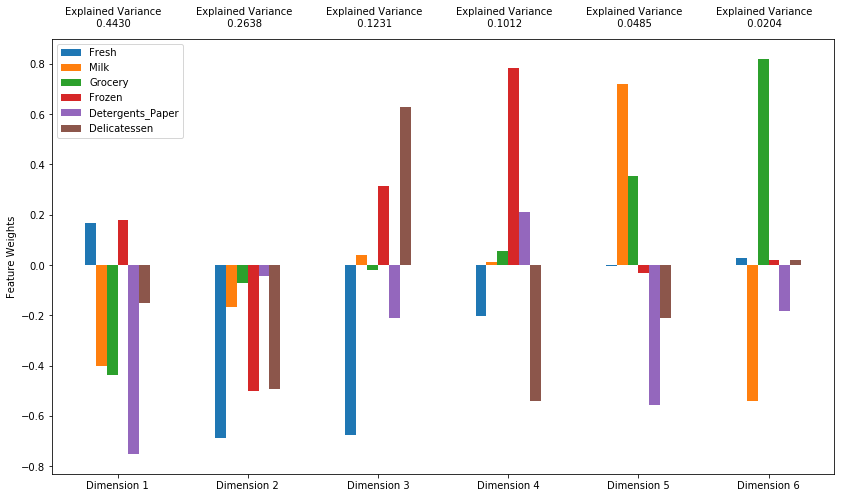

```python
# 通过在good_data上使用PCA，将其转换成和当前特征数一样多的维度
from sklearn.decomposition import PCA
import visuals as vs
pca = PCA(n_components=6)
pca.fit(good_data)
# 使用上面的PCA拟合将变换施加在log_samples上
pca_samples = pca.transform(log_samples)

# 生成PCA的结果图
pca_results = vs.pca_results(good_data, pca)
```

第一个和第二个主成分总共表示了0.71的方差；，所以完全可以将6个特征降维到2个维度

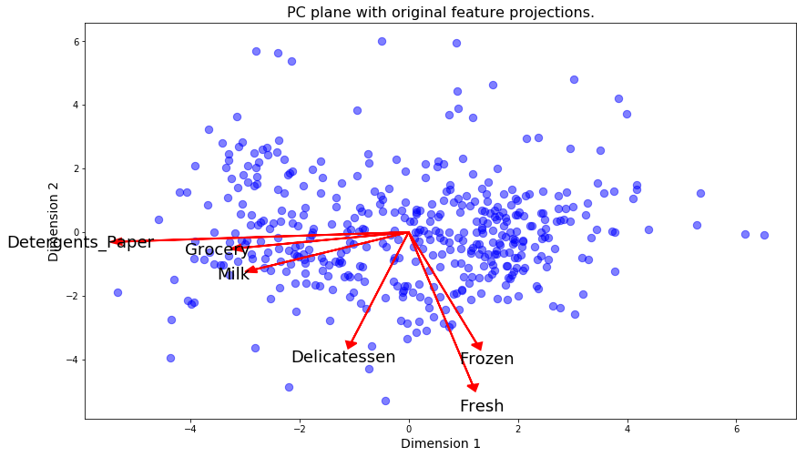

```python
# 通过在good data上进行PCA，将其转换成两个维度
pca = PCA(n_components=2)
pca.fit(good_data)
# 使用上面训练的PCA将good data进行转换
reduced_data = pca.transform(good_data)

# 使用上面训练的PCA将log_samples进行转换
pca_samples = pca.transform(log_samples)

# 为降维后的数据创建一个DataFrame
reduced_data = pd.DataFrame(reduced_data, columns = ['Dimension 1', 'Dimension 2'])
vs.biplot(good_data, reduced_data, pca)
```

```python
# 在降维后的数据上使用你选择的聚类算法
from sklearn.mixture import GaussianMixture
clusterer = GaussianMixture(n_components=2,random_state = 42)
clusterer.fit(reduced_data)
# 预测每一个点的簇
preds = clusterer.predict(reduced_data)
# 找到聚类中心
centers = clusterer.means_

# 预测在每一个转换后的样本点的类
sample_preds = clusterer.predict(pca_samples)

# 计算选择的类别的平均轮廓系数（mean silhouette coefficient）
from sklearn.metrics import silhouette_score
score = silhouette_score(reduced_data,preds)
print score
```

```
0.421916846463
```

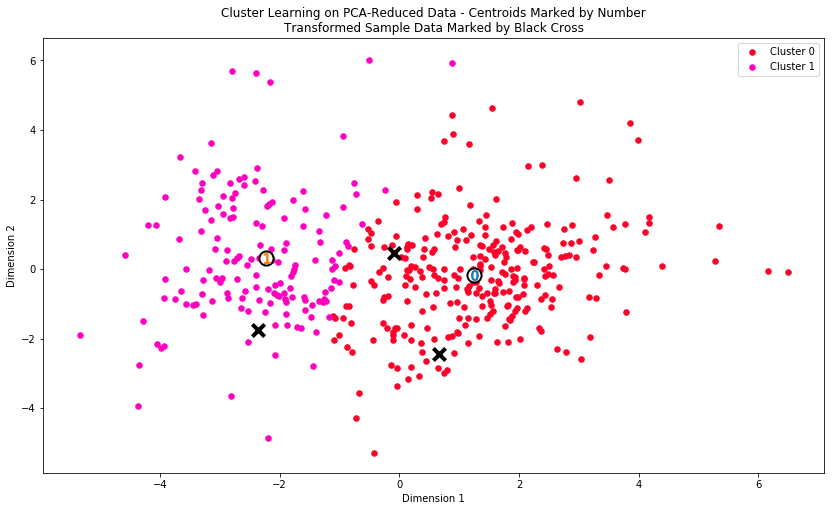

```python
# 从已有的实现中展示聚类的结果
vs.cluster_results(reduced_data, preds, centers, pca_samples)
```